# Streaming & Time Series Project

Luca Gabellini

13 giugno 2019

```r
require(xts)
library(forecast)
library(lmtest)
library(FitAR)
library(ggplot2)
require(KFAS)
require(tsfknn)
library(ggpubr)
require(MLmetrics)
```

Verranno analizzati dei dati sperimentali riguardanti il consumo di energia di elettrodomestici in un edificio a basso consumo energetico.

```r
data=read.csv("C:\\Users\\Luca\\Desktop\\BICOCCA\\streaming & time series\\progetto\\energydata_complete.csv",
                 stringsAsFactors = F)
```

Preprocessing

```r
###Appliances
#seleziono le colonne di interesse
df=data[,1:2]
#trasformo il campo date
class(df$date)
```

```
## [1] "character"
```

```r
df$date=strptime(df$date,format="%Y-%m-%d %H:%M:%S")
class(df$date)
```

```
## [1] "POSIXlt" "POSIXt"
```

```r
#ora devo aggregare per fascia oraria: 6 obs per ogni ora
#prima rimuovo l'ultima osservazione, che ha un solo valore orario al posto di 6
df=df[-(dim(df)[1]),]
```

```r
#aggrego i dati per fascia oraria
df2=aggregate(df[,'Appliances'],
                 by=list(hour=cut(as.POSIXct(df$date), "hour")),
                 FUN=sum)
names(df2)=c("Date","Appliances")
head(df2)
```

```
##                  Date Appliances
## 1 2016-01-11 17:00:00        330
## 2 2016-01-11 18:00:00       1060
## 3 2016-01-11 19:00:00       1040
## 4 2016-01-11 20:00:00        750
## 5 2016-01-11 21:00:00        620
## 6 2016-01-11 22:00:00       1600
```

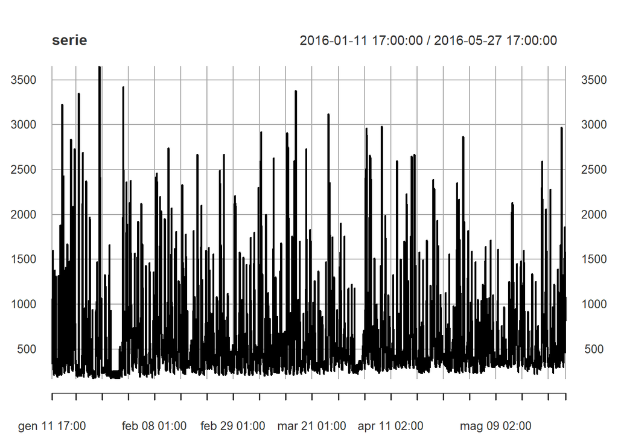

```r
serie=xts(df2$Appliances,order.by=as.POSIXct(df2$Date,format="%Y-%m-%d %H:%M:%S"))
plot(serie)
```

Seguendo lo schema classico, valuto se sussiste una relazione tra media e varianza a livello locale.

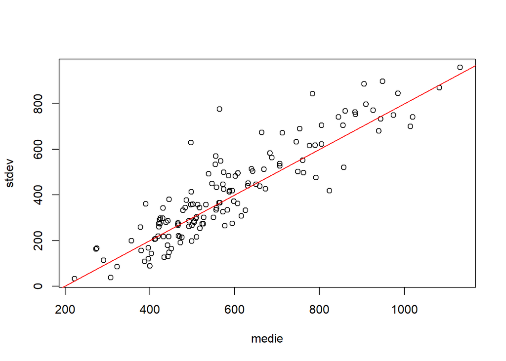

```r
medie <- tapply(serie,
                as.Date(index(serie)),
                mean)

stdev <- tapply(serie,
                as.Date(index(serie)),
                sd)

plot(medie, stdev)
abline(-200,1, col='red')
```

La relazione di linearità è evidente: applico il logaritmo

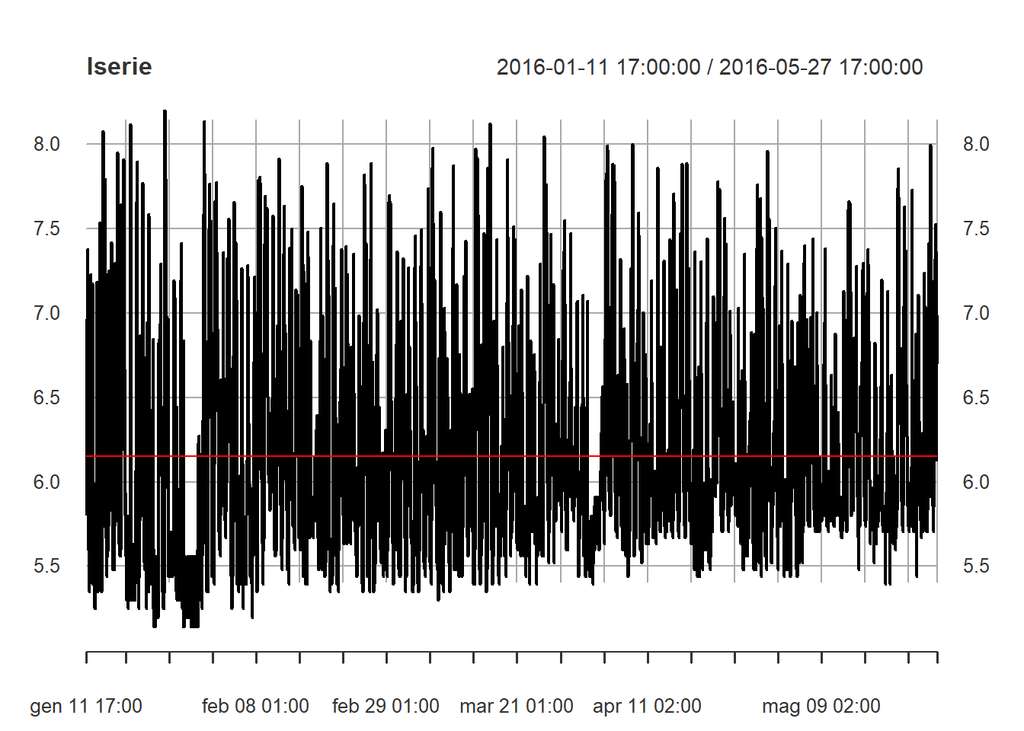

```r
lserie=log(serie)
plot(lserie)
lines(xts(rep(mean(lserie),length(lserie)),order.by=as.POSIXct(df2$Date,format="%Y-%m-%d %H:%M:%S")),col='red')
```

Dal plot della serie si possono trarre alcune osservazioni:  
- Non sembra esserci un trend positivo o negativo;  
- Sono evidenti due cali sostanziali di energia a fine gennaio e a inizio aprile;  
- La stazionarietà sui primi due momenti, ad occhio, sembra rispettata.

Si può quindi procedere nell’analisi, non prima di dividere il dataset in train e test:

```r
#Divido in train e test: train conterrà i primi 3 mesi,
#test il rimanente mese e mezzo
cutoff=which(df2['Date']=='2016-04-01 00:00:00')
test=df2[cutoff:dim(df2)[1],]
train=df2[1:(cutoff-1),]
#ritrasformo il train in una serie storica
s_train=xts(train$Appliances,order.by=as.POSIXct(train$Date,format="%Y-%m-%d %H:%M:%S"))
ltrain=log(s_train)
```

Definisco funzione per plottare assieme acf e pacf, vista a lezione:

```r
acfpacf <- function(x, max.lag=36){
  par(mfrow = c(2,1))
  Acf(x, max.lag ,main='')
  Pacf(x, max.lag, main='')
  par(mfrow = c(1,1))
}
```

Ipotizzando che, dopo la trasformazione logaritmica la serie sia ora stazionaria, analizzo acf e pacf:

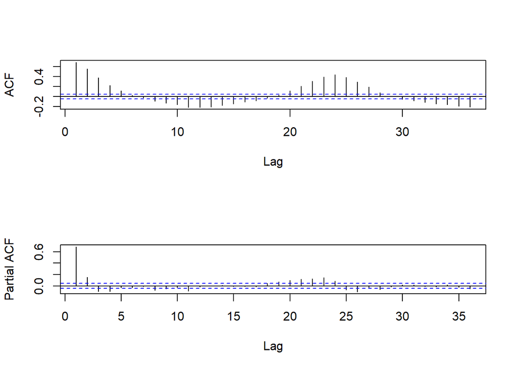

```r
acfpacf(ltrain)
```

L’acf presenta un andamento sinusoidale, che è indice della probabile presenza di una radice complessa. La pacf vede i primi quattro ritardi uscire dalle bande. Si opta per un modello AR di ordine 2, dato che solo le prime due autocorrelazioni parziali escono in maniera evidente dalle bande.

```r
mod1 <- Arima(ltrain, c(2, 0, 0), c(0, 0, 0))
coeftest(mod1)
```

```
##
## z test of coefficients:
##
##           Estimate Std. Error  z value  Pr(>|z|)
## ar1       0.582737   0.022522  25.8744 < 2.2e-16 ***
## ar2       0.152672   0.022537   6.7743  1.25e-11 ***
## intercept 6.135394   0.039909 153.7339 < 2.2e-16 ***
## ---
## Signif. codes:  0 '***' 0.001 '**' 0.01 '*' 0.05 '.' 0.1 ' ' 1
```

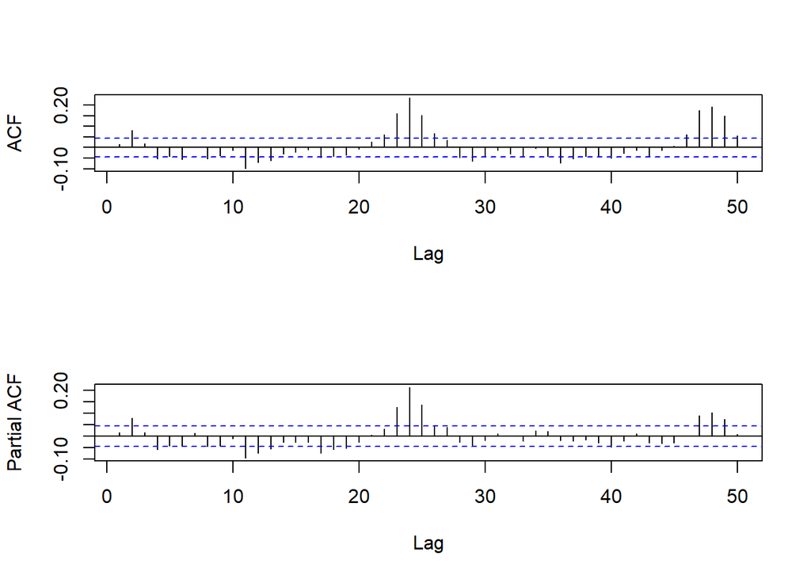

```r
acfpacf(mod1$residuals,50)
```

Dai plot acf e pacf sui residui del modello sembra esserci una stagionalità giornaliera (ogni 24 h). La parte non stagionale sembra sistemata.  
Proviamo ad aumentare il numero di residui:

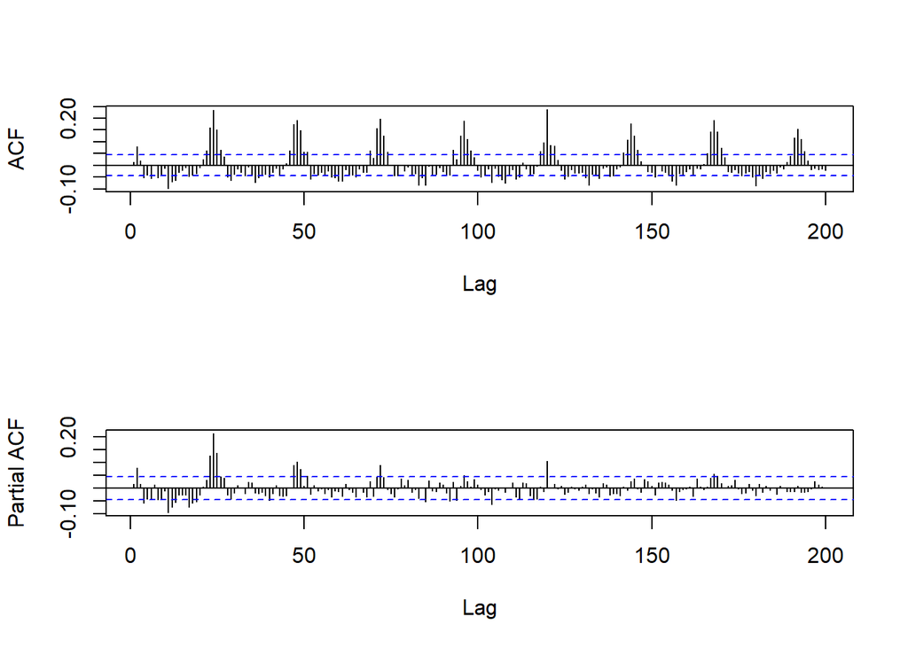

```r
acfpacf(mod1$residuals,200)
```

La stagionalità giornaliera è ancora più evidente.  
Si opta per una differenziazione stagionale:

```r
mod2 <- Arima(ltrain, order=c(2, 0, 0), seasonal=list(order=c(0, 1, 0), period=24))
coeftest(mod2)
```

```
##
## z test of coefficients:
##
##     Estimate Std. Error z value  Pr(>|z|)
## ar1 0.401621   0.022284  18.023 < 2.2e-16 ***
## ar2 0.244546   0.022302  10.965 < 2.2e-16 ***
## ---
## Signif. codes:  0 '***' 0.001 '**' 0.01 '*' 0.05 '.' 0.1 ' ' 1
```

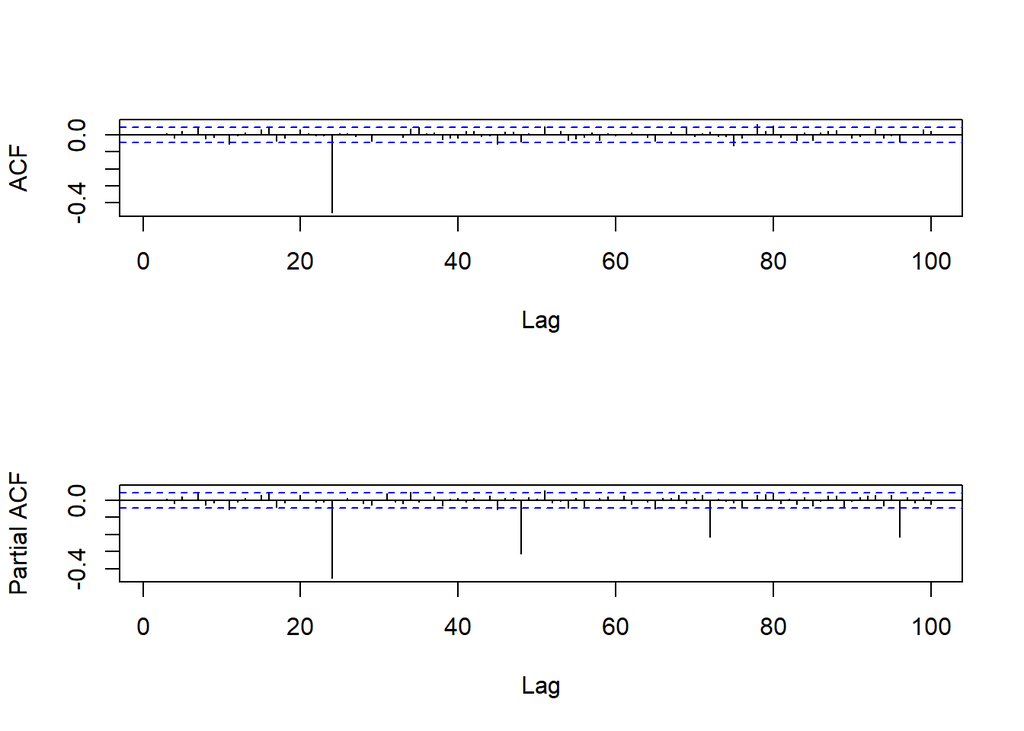

```r
acfpacf(mod2$residuals,100)
```

L’acf si annulla dopo il primo ritardo stagionale, la pacf decresce geometricamente: è evidente la presenza di un processo stagionale a media mobile (sma(1)).

```r
mod3 <- Arima(ltrain, order=c(2, 0, 0), seasonal=list(order=c(0, 1, 1), period=24))
coeftest(mod3)
```

```
##
## z test of coefficients:
##
##       Estimate Std. Error z value  Pr(>|z|)
## ar1   0.438407   0.022344  19.621 < 2.2e-16 ***
## ar2   0.228365   0.022364  10.211 < 2.2e-16 ***
## sma1 -0.957614   0.014062 -68.099 < 2.2e-16 ***
## ---
## Signif. codes:  0 '***' 0.001 '**' 0.01 '*' 0.05 '.' 0.1 ' ' 1
```

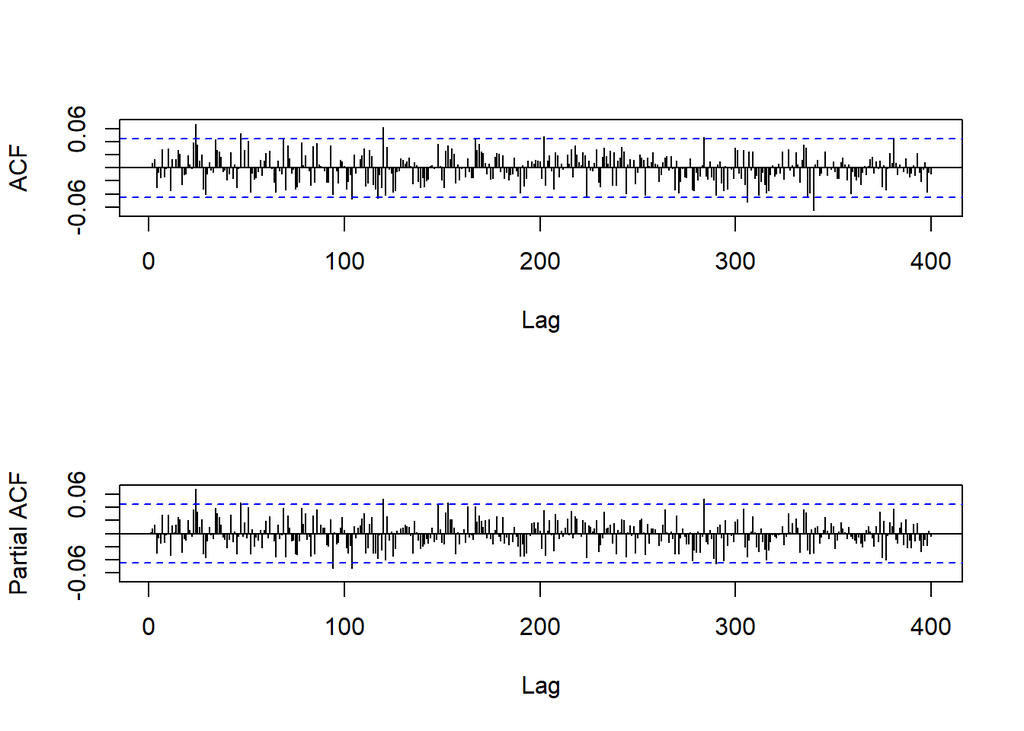

```r
acfpacf(mod3$residuals,400)
```

```r
mod4=Arima(ltrain, order=c(2, 0, 0), seasonal=list(order=c(1, 1, 1), period=24))
coeftest(mod4)
```

```
##
## z test of coefficients:
##
##       Estimate Std. Error  z value Pr(>|z|)
## ar1   0.434206   0.022394  19.3897  < 2e-16 ***
## ar2   0.229808   0.022350  10.2824  < 2e-16 ***
## sar1  0.063307   0.025130   2.5191  0.01176 *
## sma1 -0.971782   0.014761 -65.8356  < 2e-16 ***
## ---
## Signif. codes:  0 '***' 0.001 '**' 0.01 '*' 0.05 '.' 0.1 ' ' 1
```

I coefficienti sono tutti significativi, compreso quello relativo al sar(1).

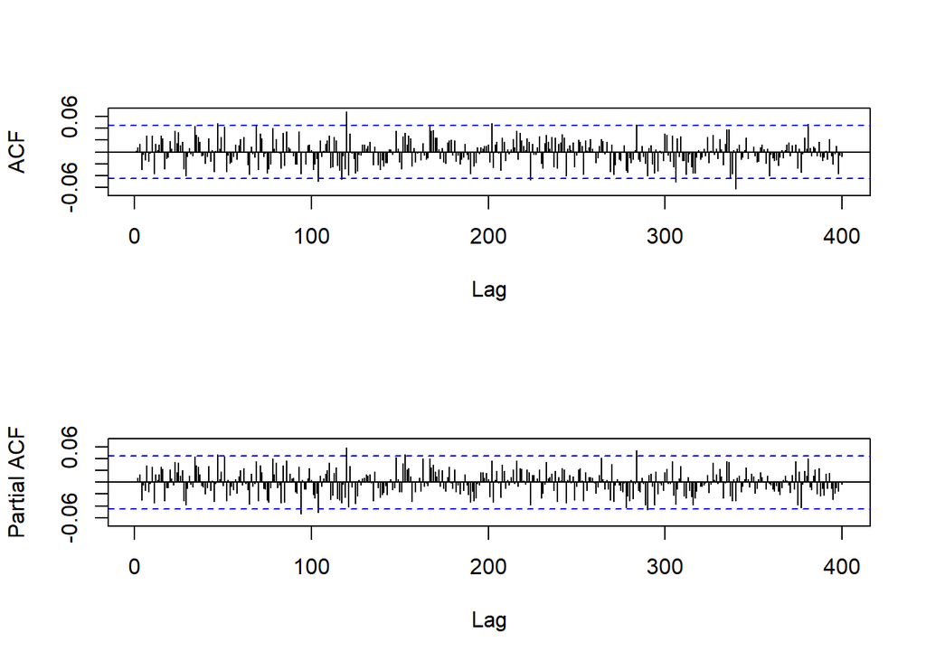

```r
acfpacf(mod4$residuals,400)
```

La situazione sul pacf è migliorata, il ritardo al lag 24 ora rientra nelle bande.  
In entrambi i grafici qualche ritardo esce dalle bande, ma considerando che il livello di confidenza è al 95% ciò è ammissibile.

Creo una funzione per il confronto tra modelli arima:

```r
confronto=function(m1,m2){
  print('statistiche primo modello')
  print(capture.output(m1)[c(2,9,10)])
  print('###########################################')
  print('statistiche secondo modello:')
  print(capture.output(m2)[c(2,9,10)])
}

confronto(mod3,mod4)
```

```
## [1] "statistiche primo modello"
## [1] "ARIMA(2,0,0)(0,1,1)[24] "
## [2] "sigma^2 estimated as 0.175:  log likelihood=-1069.69"
## [3] "AIC=2147.37   AICc=2147.39   BIC=2169.57"
## [1] "###########################################"
## [1] "statistiche secondo modello:"
## [1] "ARIMA(2,0,0)(1,1,1)[24] "
## [2] "sigma^2 estimated as 0.1739:  log likelihood=-1066.55"
## [3] "AIC=2143.09   AICc=2143.13   BIC=2170.85"
```

L’ultimo modello con sar(1) risulta di poco migliore del terzo.

La funzione auto.arima fa una selezione stepwise dei modelli Arima migliori, ovvero che massimizzano la massima verosimiglianza.  
Forzo il modello ad includere un’integrazione stagionale ponendo D=1. Non rieseguo la procedura sul markdown a causa dei tempi computazionali gravosi richiesti dall’algoritmo.

```r
#autoAR=auto.arima(ftrain, D=1)
#il modello migliore trovato dall'auto.arima è un'ARIMA(3,0,1)(2,1,0)[24]
autoAR_model=Arima(ltrain, order=c(3, 0, 1), seasonal=list(order=c(2, 1, 0), period=24))

confronto(autoAR_model,mod4)
```

```
## [1] "statistiche primo modello"
## [1] "ARIMA(3,0,1)(2,1,0)[24] "
## [2] "sigma^2 estimated as 0.2214:  log likelihood=-1264.69"
## [3] "AIC=2543.37   AICc=2543.43   BIC=2582.23"
## [1] "###########################################"
## [1] "statistiche secondo modello:"
## [1] "ARIMA(2,0,0)(1,1,1)[24] "
## [2] "sigma^2 estimated as 0.1739:  log likelihood=-1066.55"
## [3] "AIC=2143.09   AICc=2143.13   BIC=2170.85"
```

Al contrario di quanto ci si possa aspettare il modello selezionato dall’auto.arima() è decisamente peggio di mod4 in termini di AIC e log-likelihood.

Scelgo quindi il modello ARIMA(2,0,0)(1,1,1)[24] per il successivo check e forecasting.

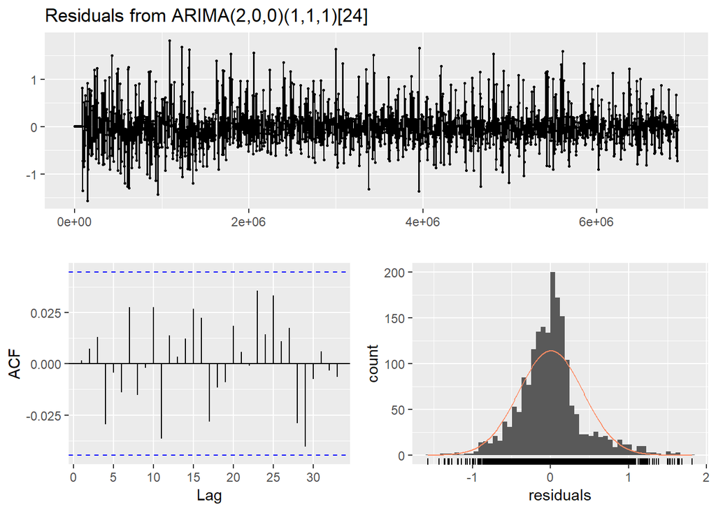

```
##
##  Ljung-Box test
##
## data:  Residuals from ARIMA(2,0,0)(1,1,1)[24]
## Q* = 280.39, df = 296, p-value = 0.7343
##
## Model df: 4.   Total lags used: 300
```

```r
checkresiduals(mod4,lag=300,plot=T)
```

Forecasting:

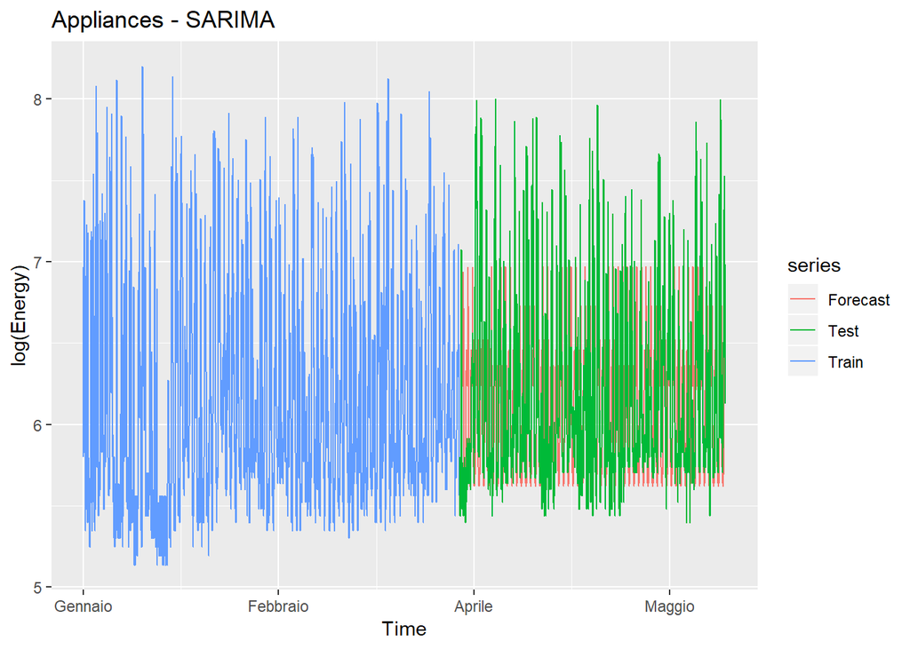

```r
s_test=xts(test$Appliances,order.by=as.POSIXct(test$Date,format="%Y-%m-%d %H:%M:%S"))
ltest=log(s_test)

#prevedo i valori futuri, tanti quante sono le osservazioni del test
forecast_arima=forecast(ltrain,h=dim(ltest)[1],model=mod4)
autoplot(ts(forecast_arima$mean,start=dim(train)[1]), series='Forecast',main = 'Appliances - SARIMA',ylab="log(Energy)") +
  autolayer(ts(log(train$Appliances)),series='Train') +
  autolayer(ts(log(test$Appliances),start=dim(train)[1]),series='Test') +
  scale_x_continuous(labels=c("Gennaio", "Febbraio", "Aprile",'Maggio'))
```

Dato che mi interessa prevedere i valori di energia originali, e non quelli log-trasformati, devo ritrasformare i valori previsti con la funzione esponenziale. In questo scenario la misura di errore ideale è il mean absolute error (MAE). Ipotizzo che la distribuzione di log(Appliances) segua approssimativamente una normale:

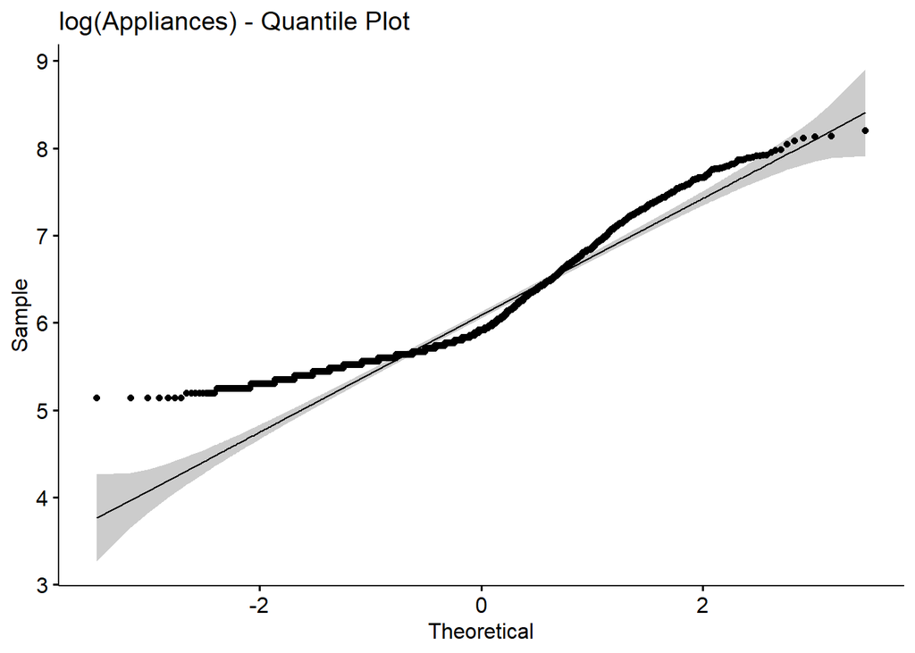

```r
ggqqplot(log(train$Appliances),main='log(Appliances) - Quantile Plot')
```

Calcolo il MAE su train e test:

```r
MAE(exp(forecast_arima$fitted),train$Appliances)
```

```
## [1] 203.6334
```

```r
MAE(exp(forecast_arima$mean),test$Appliances)
```

```
## [1] 260.1045
```

UCM

Dalle analisi fatte con i modelli Arima e dai grafici è stato visto come la serie non segua un attrattore, ma rimanga costante attorno alla propria media. Di conseguenza si implementerà un modello in forma State Space con componente trend a varianza (del livello) nulla.  
Verrà poi inclusa una componente stagionale (giornaliera) a varianza ignota, modellata con 23 dummies. La serie storica di riferimento da qui in poi sarà quella su scala naturale.

```r
mod7_kfas <- SSModel(s_train ~ 0 +
                       SSMtrend(1, 0) + #local level
                       SSMseasonal(24, NA, sea.type = "dummy"),
                     H = NA)


init7 <- c(
  logvar_eps = log(100),
  logvar_om = log(3)
)

updt7 <- function(pars, model) {
  model$H[1, 1, 1] <- exp(pars[1])
  model$Q[2, 2, 1] <- exp(pars[2]) #disturbo dummies
  model
}

fit7<- fitSSM(mod7_kfas, init7, updt7)

fit7$optim.out$convergence
```

```
## [1] 0
```

```r
round(exp(fit7$optim.out$par),3)
```

```
## logvar_eps  logvar_om
## 189997.851     11.618
```

Il trend è costante, e coincide con la media del train:

```r
smo7 <- KFS(fit7$model,
            smoothing = 'state')
plot(s_train)
mean(s_train)
```

```
## [1] 590.5971
```

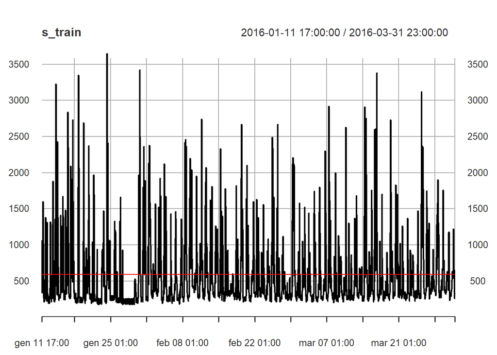

```r
lines(xts(smo7$alphahat[, "level"],order.by=as.POSIXct(train$Date,format="%Y-%m-%d %H:%M:%S")),
      col = "red")
```

La componente stagionale è praticamente deterministica:

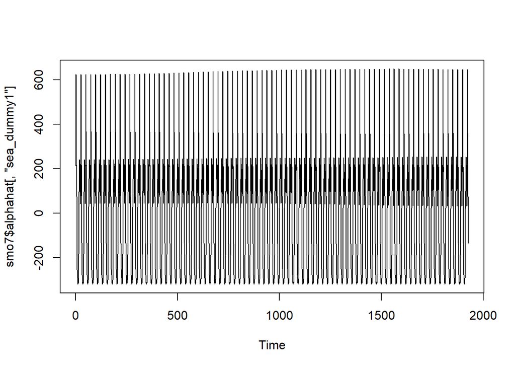

```r
plot(smo7$alphahat[, "sea_dummy1"], type = "l")
```

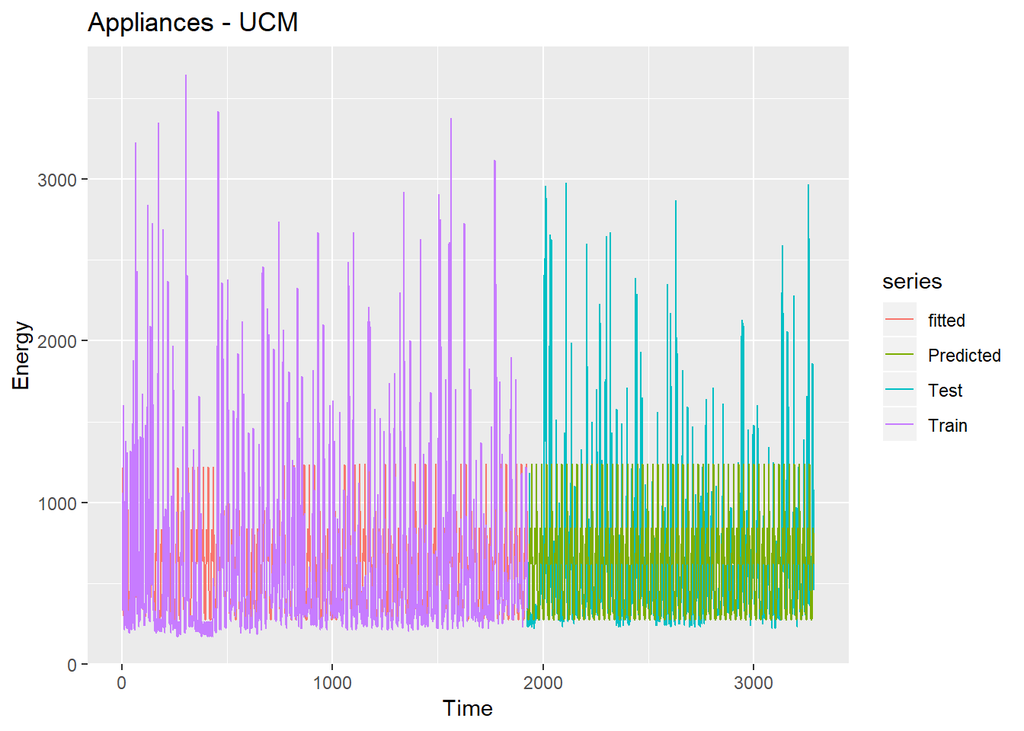

```r
kfas_pred=predict(fit7$model,n.ahead=dim(s_test)[1])

autoplot(fitted(fit7$model), series='fitted',main = 'Appliances - UCM',ylab="Energy") +
  xlim(c(0, 3288)) +
  autolayer(ts(train$Appliances),series='Train') +
  autolayer(ts(test$Appliances,start=dim(train)[1]), series='Test') +
  autolayer(kfas_pred,series='Predicted')
```

Il modello, data anche la natura delle sue componenti, è di fatto deterministico. Le previsioni dell’UCM sono simili a quelle del modello ARIMA: il modello fatica a cogliere i numerosi picchi (positivi e negativi) della serie originale.

Per cercare di prevedere meglio i picchi sono state considerate svariate configurazioni di modelli UCM; tra le più significative una con trend costante e due componenti stagionali, una giornaliera, l’altra quadrisettimanale:

```r
kfas_mod3 <- SSModel(s_train ~ 0 +
                       SSMtrend(1, 0) + #1 corresponds to local level (random walk)
                       SSMseasonal(24, NA, sea.type = "dummy") +
                       SSMseasonal(672, NA, sea.type = "trig", harmonics=1:16), #metto un numero limitato di sinusoidi, 16,
                     H = NA)                                                    #come visto a lezione


inits3<- c(
  logvar_eps = log(100),
  logvar_om = log(3),
  logvar_om2 = log(2)
)

updt3 <- function(pars, model) {
  dq <- dim(model$Q)[1]
  model$H[1, 1, 1] <- exp(pars[1])
  model$Q[2, 2, 1] <- exp(pars[2]) #disturbo dummies
  diag(model$Q[3:dq, 3:dq, 1]) <- exp(pars[3]) #dq-3 disturbi per la 2a stag
  model
}

fit3 <- fitSSM(kfas_mod3, inits3, updt3)
fit3$optim.out$convergence
```

```
## [1] 0
```

```r
round(exp(fit3$optim.out$par),3)
```

```
## logvar_eps  logvar_om logvar_om2
## 154763.193      0.005     17.924
```

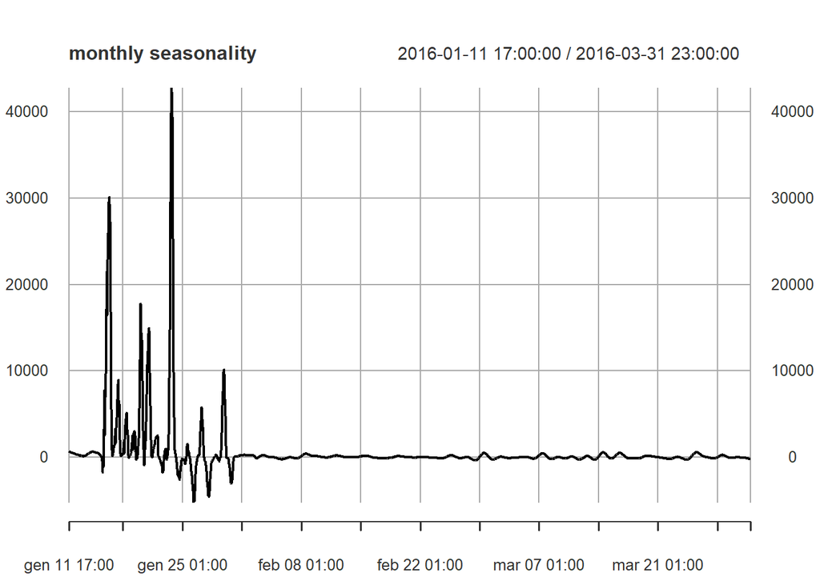

```r
smo3 <- KFS(fit3$model, smoothing='state')

#plot stag. mensile
plot(xts(rowSums(
  smo3$alphahat[, paste0("sea_trig", 1:16)]),order.by=as.POSIXct(train$Date,format="%Y-%m-%d %H:%M:%S")),
  type = "l",main='monthly seasonality') #
```

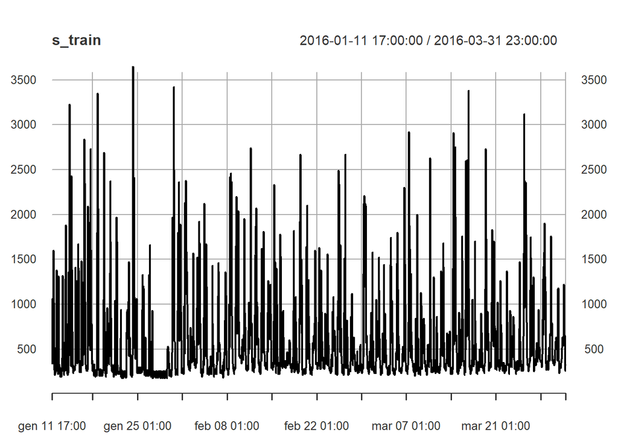

```r
plot(s_train)
```

La seconda componente stagionale riusciva a cogliere bene i picchi positivi e negativi, in particolare quelli di Gennaio.  
La procedura di ottimizzazione del modello andava però a stimare varianze delle componenti enormi, e un modello finale degenere. Fissando le varianze a priori non infinite, ma su valori più contenuti, il risultato finale non cambiava.  
Per questo si prende come modello UCM di riferimento il primo (fit7$model), con trend costante e stagionalità giornaliera.

Calcolo il MAE su train e test:

```r
MAE(fitted(fit7$model),train$Appliances)
```

```
## [1] 267.1239
```

```r
MAE(kfas_pred,test$Appliances)
```

```
## [1] 296.2457
```

Machine Learning

Per quanto riguarda la parte di machine learning sono stati utilizzati dei modelli KNN. La funzione knn_forecasting() permette in una sola riga di codice di specificare il modello KNN voluto e fare previsioni. Il pacchetto è stato reso disponibile agli utenti R di recente, il 31 maggio 2019. Per informazioni più dettagliate sull’algoritmo si rimanda al report e al seguente link: https://cran.r-project.org/web/packages/tsfknn/vignettes/tsfknn.html

La funzione ha come argomenti principali: • La serie da prevedere • Il parametro h, ovvero il numero di step di previsione • Lags: numero di lag utilizzati per la previsione • Il parametro k, ovvero il numero di vicini da considerare • Msas: la strategia di previsione utilizzata.

Sono state provate differenti combinazioni di lags e k (numero di vicini). Vengono proposti i due modelli migliori:  
-knn_m6, con k=3 e lags giornaliero;  
-knn_m8, con k=3 e lag settimanale.

```r
knn_m6=knn_forecasting(ts(s_train),h=dim(s_test)[1],lags=1:24,k=3, msas='recursive')
```

Plot della procedura di forecasting del modello knn_m6:

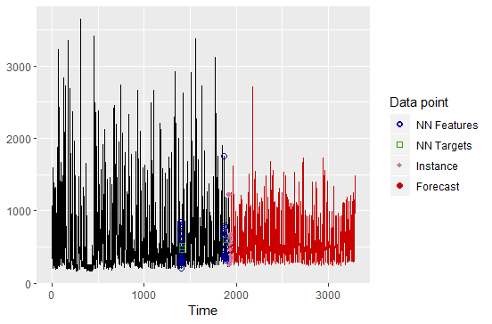

```r
autoplot(knn_m6, highlight = "neighbors", faceting = FALSE)
```

```r
knn_m8=knn_forecasting(ts(s_train),h=dim(s_test)[1],lags=1:168, k=3, msas='recursive')
```

Plot della procedura di forecasting del modello knn_m8:

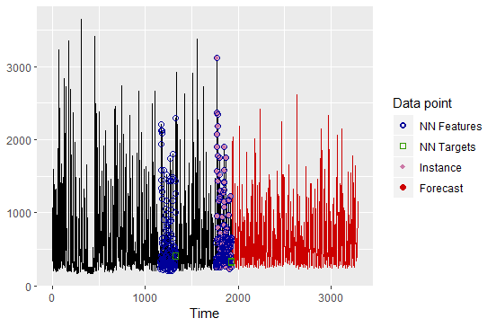

```r
autoplot(knn_m8, highlight = "neighbors", faceting = FALSE)
```

Plot dei valori previsti vs reali:

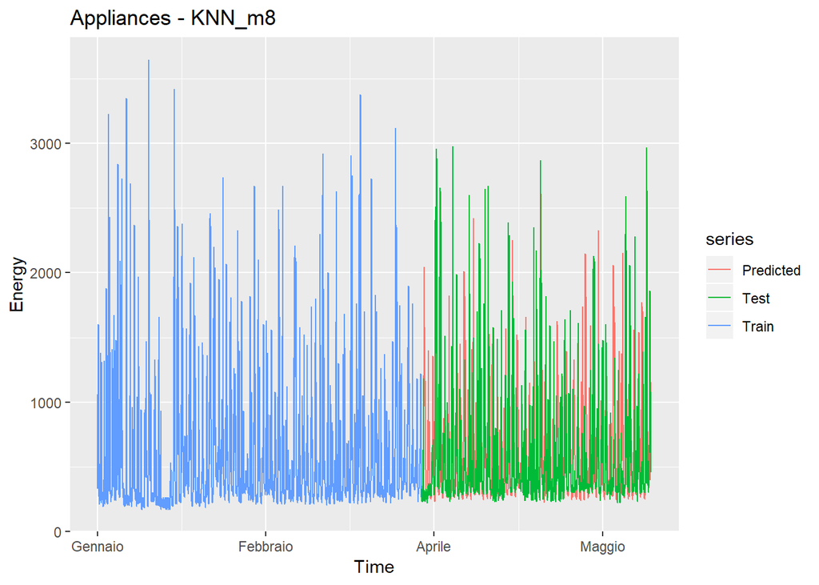

```r
autoplot(knn_m8$prediction, series='Predicted',main = 'Appliances - KNN_m8',ylab="Energy") +
  autolayer(ts(train$Appliances),series='Train') +
  autolayer(ts(test$Appliances,start=dim(train)[1]), series='Test') +
  scale_x_continuous(labels=c("Gennaio", "Febbraio", "Aprile",'Maggio'))
```

Graficamente le previsioni appaiono buone, anche se spesso i picchi previsti non si sovrappongono con quelli reali della serie.

Confronto dei due modelli migliori con MAE:

```r
MAE(knn_m6$prediction,test$Appliances)
```

```
## [1] 344.1361
```

```r
MAE(knn_m8$prediction,test$Appliances)
```

```
## [1] 291.6251
```

Il modello knn migliore risulta quello con 168 lag.